# Oracle Operations POC using UCI Bank Marketing Dataset

# Flow of Oracle POC

1. Data visualisations on input dataset
2. Data cleaning
3. Categorical encoding
4. Data visualisations on cleaned dataset
5. Clustering & feature engineering using k-means clustering
6. Final dataset
7. Train test split and SMOTE
8. Logistic regression models with stratified 10-fold cross validation(cv)
9. CART models with 10-fold cv
10. XGBoost model with stratified 10-fold cv
11. XGBoost feature importance
12. Boruta feature selection
13. Optimised XGBoost using Boruta features with stratified 10-fold cv
14. XGBoost for Boruta data & HR data with stratified 10-fold cv
15. XGBoost for Boruta data & Investment data with stratified 10-fold cv
16. XGBoost for Boruta data & HR & Investment data with stratified 10-fold cv
17. Optimised XGBoost from (17) with hyperparameter tuning

# Import libraries

```r
# data table
library(data.table)
# data visualisation
library(gmodels)
library(corrplot)
library(caTools)
library(ggplot2)
library(reshape2)
library(caTools)
library(ggridges)
library(scales)
library(ggmosaic)
library(cluster)
library(gridExtra)
library(factoextra)
# data cleaning
library(mltools)
library(DMwR)
library(dplyr)
# feature selection
library(Boruta)
library(rFerns)
# predictive modelling
library(rpart)
library(rpart.plot)
library(xgboost)
library(caret)
library(cluster)
```

# Our Problem

Reducing labour costs through the automation of operational processes.

# Read csv data

```r
bankData <-fread("C:/Users/qingy/OneDrive/Documents/BC2406 Analytics I/Project/bank-full.csv", stringsAsFactors = TRUE)
#bankData <-fread("bank-full.csv", stringsAsFactors = TRUE)
head(bankData)
```

| age | job | marital | education | default | balance | housing | loan | contact | day | month | duration | campaign | pdays | previous | poutcome | y |
| --- | --- | --- | --- | --- | --- | --- | --- | --- | --- | --- | --- | --- | --- | --- | --- | --- |
| 58 | management | married | tertiary | no | 2143 | yes | no | unknown | 5 | may | 261 | 1 | -1 | 0 | unknown | no |
| 44 | technician | single | secondary | no | 29 | yes | no | unknown | 5 | may | 151 | 1 | -1 | 0 | unknown | no |
| 33 | entrepreneur | married | secondary | no | 2 | yes | yes | unknown | 5 | may | 76 | 1 | -1 | 0 | unknown | no |
| 47 | blue-collar | married | unknown | no | 1506 | yes | no | unknown | 5 | may | 92 | 1 | -1 | 0 | unknown | no |
| 33 | unknown | single | unknown | no | 1 | no | no | unknown | 5 | may | 198 | 1 | -1 | 0 | unknown | no |
| 35 | management | married | tertiary | no | 231 | yes | no | unknown | 5 | may | 139 | 1 | -1 | 0 | unknown | no |

# Exploratory Data Analysis

### Size of dataset

```r
dim(bankData)
```

```
[1] 45211    17
```

### Column names of dataset

```r
names(bankData)
```

```
 [1] "age"       "job"       "marital"   "education" "default"   "balance"   "housing"   "loan"      "contact"
[10] "day"       "month"     "duration"  "campaign"  "pdays"     "previous"  "poutcome"  "y"
```

### Statistical Summary of dataset

```r
summary(bankData)
```

```
      age                 job           marital          education     default        balance       housing
 Min.   :18.00   blue-collar:9732   divorced: 5207   primary  : 6851   no :44396   Min.   : -8019   no :20081
 1st Qu.:33.00   management :9458   married :27214   secondary:23202   yes:  815   1st Qu.:    72   yes:25130
 Median :39.00   technician :7597   single  :12790   tertiary :13301               Median :   448
 Mean   :40.94   admin.     :5171                    unknown  : 1857               Mean   :  1362
 3rd Qu.:48.00   services   :4154                                                  3rd Qu.:  1428
 Max.   :95.00   retired    :2264                                                  Max.   :102127
                 (Other)    :6835
  loan            contact           day            month          duration         campaign
 no :37967   cellular :29285   Min.   : 1.00   may    :13766   Min.   :   0.0   Min.   : 1.000
 yes: 7244   telephone: 2906   1st Qu.: 8.00   jul    : 6895   1st Qu.: 103.0   1st Qu.: 1.000
             unknown  :13020   Median :16.00   aug    : 6247   Median : 180.0   Median : 2.000
                               Mean   :15.81   jun    : 5341   Mean   : 258.2   Mean   : 2.764
                               3rd Qu.:21.00   nov    : 3970   3rd Qu.: 319.0   3rd Qu.: 3.000
                               Max.   :31.00   apr    : 2932   Max.   :4918.0   Max.   :63.000
                                               (Other): 6060
     pdays          previous           poutcome       y
 Min.   : -1.0   Min.   :  0.0000   failure: 4901   no :39922
 1st Qu.: -1.0   1st Qu.:  0.0000   other  : 1840   yes: 5289
 Median : -1.0   Median :  0.0000   success: 1511
 Mean   : 40.2   Mean   :  0.5803   unknown:36959
 3rd Qu.: -1.0   3rd Qu.:  0.0000
 Max.   :871.0   Max.   :275.0000
```

### Check for null values

```r
sum(is.na(bankData))    ## no NA in dataset
```

```
[1] 0
```

### Rename output variable, y, to response for greater clarity in analysis

```r
# Rename column y to response
names(bankData)[names(bankData) == "y"] <- "response"
```

### Response - The clients subscribed a term deposit? (binary: ‘yes’, ‘no’)

```r
CrossTable(bankData$response)
```

```
   Cell Contents
|-------------------------|
|                       N |
|         N / Table Total |
|-------------------------|


Total Observations in Table:  45211


          |        no |       yes |
          |-----------|-----------|
          |     39922 |      5289 |
          |     0.883 |     0.117 |
          |-----------|-----------|
```

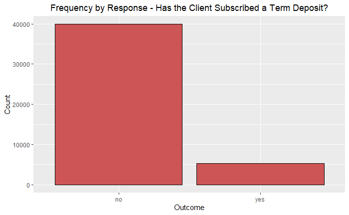

```r
ggplot(bankData, aes(x = response)) +
  geom_bar(fill = "indianred3", colour="black") +
  labs(x = "Outcome",
       y = "Count",
       title = "Frequency by Response - Has the Client Subscribed a Term Deposit?") +
  theme(plot.title = element_text(hjust = 0.5))
```

## Data Visualization:

### Univariate Numeric Analysis

```r
bankNum = bankData[, lapply(bankData, is.numeric) == TRUE, with = FALSE, ]
head(bankNum)
```

| age | balance | day | duration | campaign | pdays | previous |
| --- | --- | --- | --- | --- | --- | --- |
| 58 | 2143 | 5 | 261 | 1 | -1 | 0 |
| 44 | 29 | 5 | 151 | 1 | -1 | 0 |
| 33 | 2 | 5 | 76 | 1 | -1 | 0 |
| 47 | 1506 | 5 | 92 | 1 | -1 | 0 |
| 33 | 1 | 5 | 198 | 1 | -1 | 0 |
| 35 | 231 | 5 | 139 | 1 | -1 | 0 |

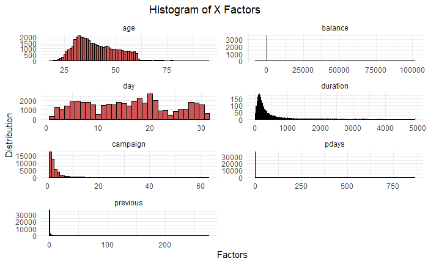

```r
ggplot(melt(bankNum), aes(x = value)) +
    facet_wrap(~ variable, scales = "free", ncol = 2) +
    geom_histogram(binwidth = 1, fill = "indianred3", colour="black")+
    theme_minimal()+
    labs(x = "Factors", y = "Distribution", title = "Histogram of X Factors") +
    theme(plot.title = element_text(hjust = 0.4))
```

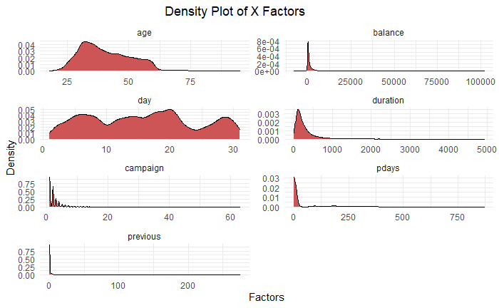

```r
# Create a kernel density plot of age
ggplot(melt(bankNum), aes(x = value)) +
  facet_wrap(~ variable, scales = "free", ncol = 2) +
  geom_density(fill = "indianred3")+
  theme_minimal()+
  labs(x = "Factors", y = "Density", title = "Density Plot of X Factors") +
  theme(plot.title = element_text(hjust = 0.4))
```

### Univariate Categorical Analysis

```r
bankCat = bankData[, lapply(bankData, is.factor) == TRUE, with = FALSE, ]
head(bankCat)
```

| job | marital | education | default | housing | loan | contact | month | poutcome | response |
| --- | --- | --- | --- | --- | --- | --- | --- | --- | --- |
| management | married | tertiary | no | yes | no | unknown | may | unknown | no |
| technician | single | secondary | no | yes | no | unknown | may | unknown | no |
| entrepreneur | married | secondary | no | yes | yes | unknown | may | unknown | no |
| blue-collar | married | unknown | no | yes | no | unknown | may | unknown | no |
| unknown | single | unknown | no | no | no | unknown | may | unknown | no |
| management | married | tertiary | no | yes | no | unknown | may | unknown | no |

```
attributes are not identical across measure variables; they will be dropped
```

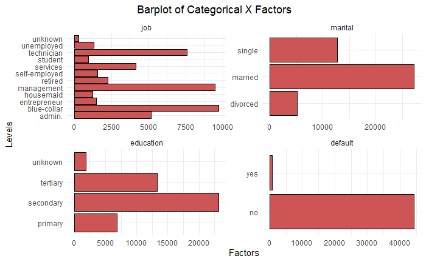

```r
bankCat1= bankCat[, c("job", "marital", "education","default", "response")]
ggplot(melt(bankCat1, id.vars="response"), aes(y = value)) +
  facet_wrap(~ variable, scales = "free", ncol=2) +
  geom_bar(fill = "indianred3", color="black")+
  theme_minimal()+
  labs(x = "Factors", y = "Levels", title = "Barplot of Categorical X Factors") +
  theme(plot.title = element_text(hjust = 0.35))
```

```
attributes are not identical across measure variables; they will be dropped
```

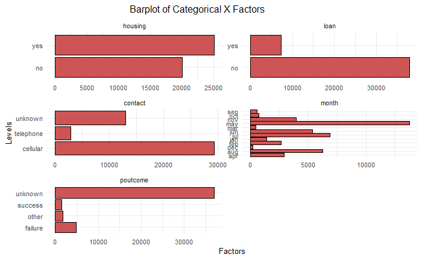

```r
bankCat2= bankCat[, c("housing","loan","contact","month","poutcome", "response")]
ggplot(melt(bankCat2, id.vars="response"), aes(y = value)) +
  facet_wrap(~ variable, scales = "free", ncol=2) +
  geom_bar(fill = "indianred3",
           color="black")+
  theme_minimal()+
  theme(text = element_text(size=10))+
  labs(x = "Factors", y = "Levels", title = "Barplot of Categorical X Factors") +
  theme(plot.title = element_text(hjust = 0.35))
```

### Bivariate Analysis

```r
bankNum1 = bankNum[, response := bankData$response]
```

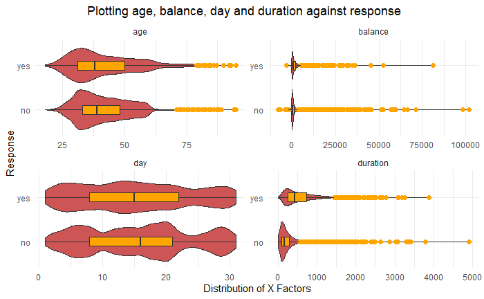

```r
# plot the distribution using violin and boxplots
bankNum2 = bankNum1[,c("age", "balance", "day", "duration", "response")]
ggplot(melt(bankNum2, id.vars="response"),
       aes(x = value,
           y = response)) +
  facet_wrap(~ variable, scales = "free", ncol=2) +
  geom_violin(fill = "indianred3") +
  geom_boxplot(width = .2,
               fill = "orange",
               outlier.color = "orange",
               outlier.size = 2)+
  theme_minimal()+
  labs(x = "Distribution of X Factors", y = "Response", title = "Plotting age, balance, day and duration against response") +
  theme(plot.title = element_text(hjust = 0.4))
```

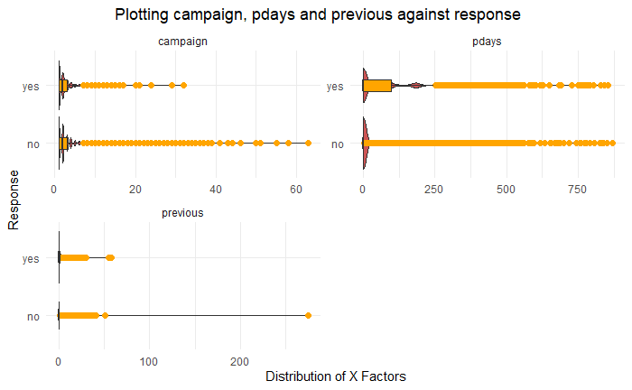

```r
# plot the distribution using violin and boxplots
bankNum3 = bankNum1[,c("campaign", "pdays", "previous", "response")]
ggplot(melt(bankNum3, id.vars="response"),
       aes(x = value,
           y = response)) +
  facet_wrap(~ variable, scales = "free", ncol=2) +
  geom_violin(fill = "indianred3") +
  geom_boxplot(width = .2,
               fill = "orange",
               outlier.color = "orange",
               outlier.size = 2)+
  theme_minimal()+
  labs(x = "Distribution of X Factors", y = "Response", title = "Plotting campaign, pdays and previous against response") +
  theme(plot.title = element_text(hjust = 0.4))
```

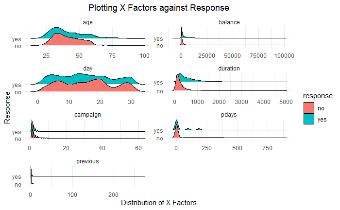

```r
ggplot(melt(bankNum1, id.vars="response"),
       aes(x = value,
           y = response,
           fill = response)) +
  facet_wrap(~ variable, scales = "free", ncol=2) +
  geom_density_ridges() +
  theme_ridges()+
  theme_minimal()+
  labs(x = "Distribution of X Factors", y = "Response", title = "Plotting X Factors against Response") +
  theme(plot.title = element_text(hjust = 0.5))
```

```
attributes are not identical across measure variables; they will be dropped
```

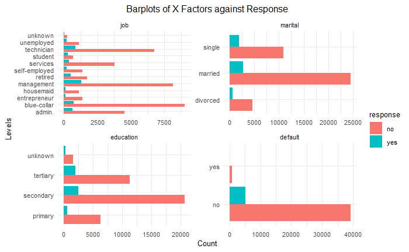

```r
bankCat1 = bankCat[, response := bankData$response]
# plot the distribution using violin and boxplots
# Grouped bar chart relationship between job and marital status
bankCat2 = bankCat1[,c("job", "marital", "education", "default", "response")]
ggplot(melt(bankCat2, id.vars="response"),
       aes(y = value,
           fill = response)) +
  facet_wrap(~ variable, scales = "free", ncol=2) +
  geom_bar(position = "dodge") +
  theme_minimal()+
  labs(x = "Count", y = "Levels", title = "Barplots of X Factors against Response")+
  theme(plot.title = element_text(hjust = 0.5))+
  theme(text = element_text(size=10))
```

```
attributes are not identical across measure variables; they will be dropped
```

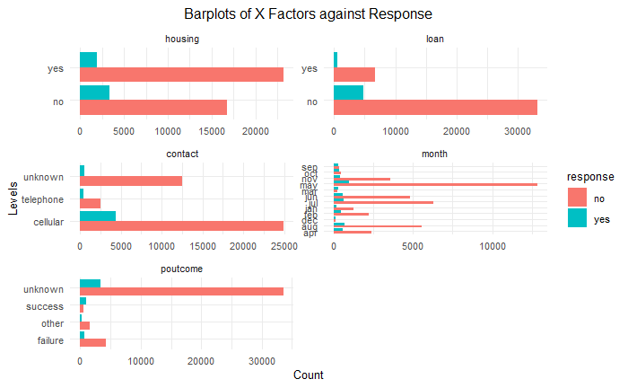

```r
bankCat3 = bankCat1[,c("housing", "loan", "contact", "month","poutcome", "response")]
ggplot(melt(bankCat3, id.vars="response"),
       aes(y = value,
           fill = response)) +
  facet_wrap(~ variable, scales = "free", ncol=2) +
  geom_bar(position = "dodge") +
  theme_minimal()+
  labs(x = "Count", y = "Levels", title = "Barplots of X Factors against Response")+
  theme(plot.title = element_text(hjust = 0.5))+
  theme(text = element_text(size=10))
```

```
attributes are not identical across measure variables; they will be dropped
```

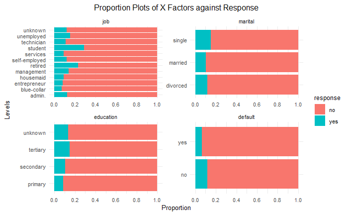

```r
ggplot(melt(bankCat2, id.vars="response"),
       aes(y = value,
           fill = response)) +
  facet_wrap(~ variable, scales = "free", ncol=2) +
  geom_bar(position = "fill") +
  scale_x_continuous(breaks = seq(0, 1, .2)) +
  theme_minimal()+
  theme(text = element_text(size=10))+
  labs(x = "Proportion", y = "Levels", title = "Proportion Plots of X Factors against Response")+
  theme(plot.title = element_text(hjust = 0.5))
```

```
attributes are not identical across measure variables; they will be dropped
```

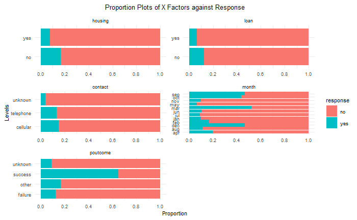

```r
ggplot(melt(bankCat3, id.vars="response"),
       aes(y = value,
           fill = response)) +
  facet_wrap(~ variable, scales = "free", ncol=2) +
  geom_bar(position = "fill") +
  scale_x_continuous(breaks = seq(0, 1, .2)) +
  theme_minimal()+
  theme(text = element_text(size=8))+
  labs(x = "Proportion", y = "Levels", title = "Proportion Plots of X Factors against Response")+
  theme(plot.title = element_text(hjust = 0.5))
```

## Data visualisations on customer data

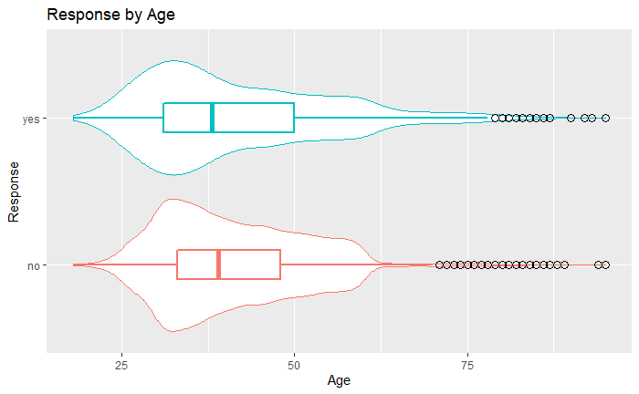

```r
# plot the distribution of age
ggplot(bankNum1,
       aes(x = response,
           y = age,
           color = response)) +
  geom_violin() +
  geom_boxplot(size=1,
               width = .2,
               outlier.shape = 1,
               outlier.color = "black",
               outlier.size  = 3) +
  scale_y_continuous() +
  labs(title = "Response by Age",
       x = "Response",
       y = "Age") +
  theme(legend.position = "none") +
  coord_flip()
```

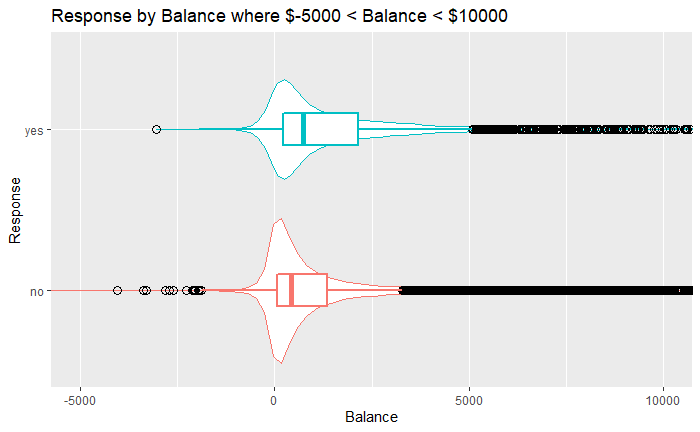

```r
ggplot(bankNum1,
       aes(y = response,
           x = balance,
           color = response)) +
  geom_violin() +
  geom_boxplot(size=1,
               width = .2,
               outlier.shape = 1,
               outlier.color = "black",
               outlier.size  = 3) +
  labs(title = "Response by Balance where $-5000 < Balance < $10000",
       y = "Response",
       x = "Balance") +
  theme(legend.position = "none") +
coord_cartesian(xlim = c(-5000, 10000))
```

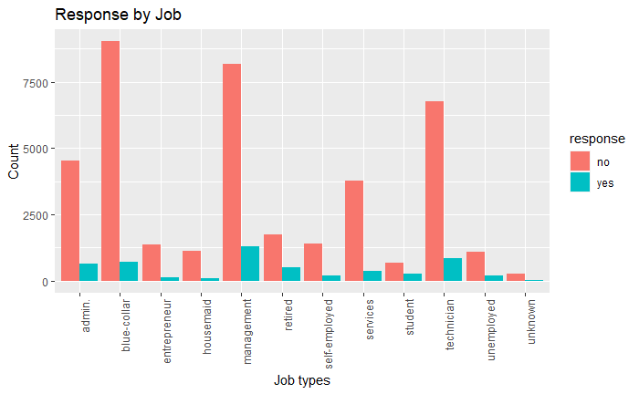

```r
# grouped bar chart
ggplot(data = bankData, aes(x = job,fill = response)) + geom_bar(position = "dodge")  +
  theme(axis.text.x = element_text(angle = 90, hjust = 1)) +
  labs(y = "Count", x = "Job types", title = "Response by Job")
```

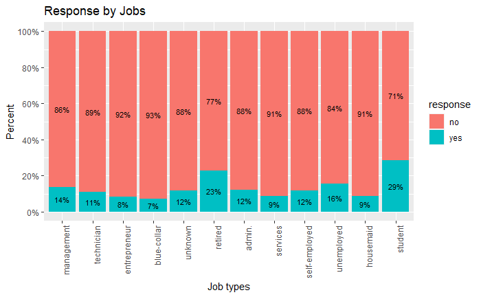

```r
# stacked bar chart with percentages
plotdata <- bankData %>%
  group_by(job, response) %>%
  summarize(n = n()) %>%
  mutate(pct = n/sum(n),
         lbl = scales::percent(pct))
ggplot(plotdata,
       aes(x= factor(job,
                      levels = unique(bankData$job)),
           y = pct,
           fill = factor(response,
                         levels = c("no", "yes"),
                         labels = c("no", "yes")))) +
  geom_bar(stat = "identity",
           position = "fill") +
  scale_y_continuous(breaks = seq(0, 1, .2),
                     label = percent) +
  geom_text(aes(label = lbl),
            size = 3,
            position = position_stack(vjust = 0.5)) +
  labs(x = "Job types", y = "Percent", title = "Response by Jobs", fill="response")+
  theme(axis.text.x = element_text(angle = 90, hjust = 1))
```

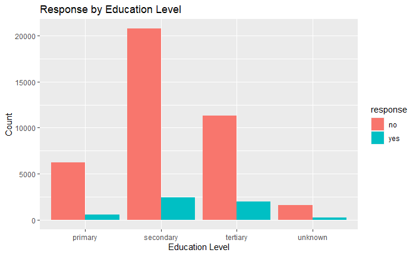

```r
# grouped bar chart
ggplot(data = bankData, aes(x = education,fill = response)) + geom_bar(position = "dodge")  +
  theme() +
  labs(y = "Count", x = "Education Level", title = "Response by Education Level")
```

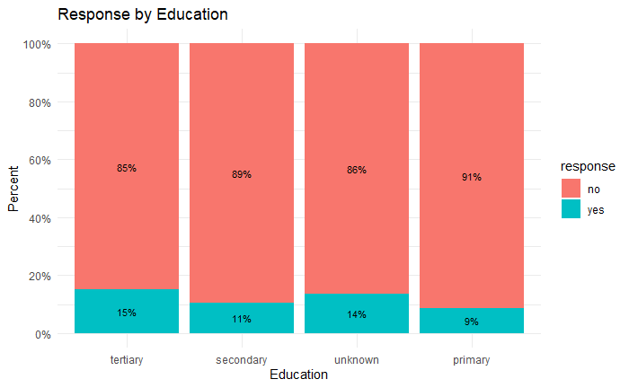

```r
# stacked bar chart with percentages
plotdata <- bankData %>%
  group_by(education, response) %>%
  summarize(n = n()) %>%
  mutate(pct = n/sum(n),
         lbl = scales::percent(pct))
ggplot(plotdata,
       aes(x= factor(education,
                      levels = unique(bankData$education)),
           y = pct,
           fill = factor(response,
                         levels = c("no", "yes"),
                         labels = c("no", "yes")))) +
  geom_bar(stat = "identity",
           position = "fill") +
  scale_y_continuous(breaks = seq(0, 1, .2),
                     label = percent) +
  geom_text(aes(label = lbl),
            size = 3,
            position = position_stack(vjust = 0.5)) +
  labs(x = "Education", y = "Percent", title = "Response by Education", fill="response")+
  theme_minimal()
```

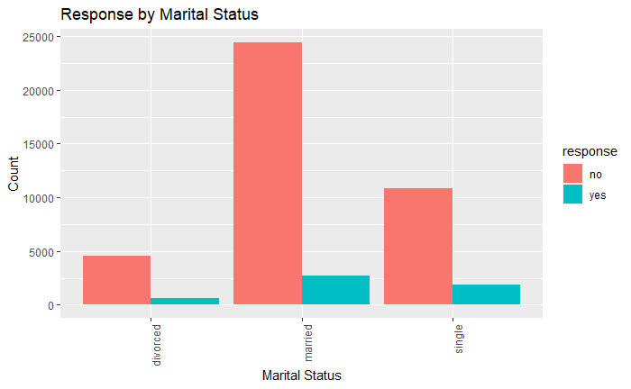

```r
# grouped bar chart
ggplot(data = bankData, aes(x = marital,fill = response)) + geom_bar(position = "dodge")  +
  theme(axis.text.x = element_text(angle = 90, hjust = 1)) +
  labs(y = "Count", x = "Marital Status", title = "Response by Marital Status")
```

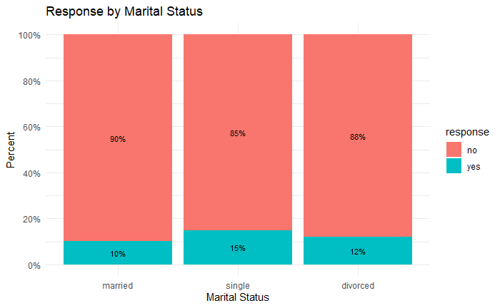

```r
# stacked bar chart with percentages
plotdata <- bankData %>%
  group_by(marital, response) %>%
  summarize(n = n()) %>%
  mutate(pct = n/sum(n),
         lbl = scales::percent(pct))
ggplot(plotdata,
       aes(x = factor(marital,
                      levels = unique(bankData$marital)),
           y = pct,
           fill = factor(response,
                         levels = c("no", "yes"),
                         labels = c("no", "yes")))) +
  geom_bar(stat = "identity",
           position = "fill") +
  scale_y_continuous(breaks = seq(0, 1, .2),
                     label = percent) +
  geom_text(aes(label = lbl),
            size = 3,
            position = position_stack(vjust = 0.5)) +
  labs(x = "Marital Status", y = "Percent", title = "Response by Marital Status", fill="response")+
  theme_minimal()
```

## Data Visualisations on telemarketing data

Duration

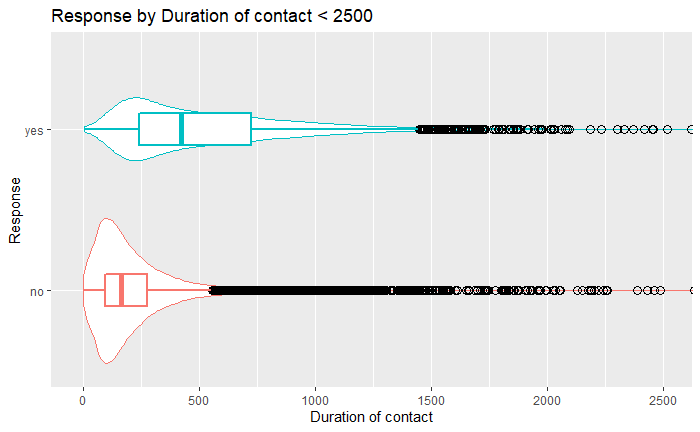

```r
ggplot(bankNum1,
       aes(y = response,
           x = duration,
           color = response)) +
  geom_violin() +
  geom_boxplot(size=1,
               width = .2,
               outlier.shape = 1,
               outlier.color = "black",
               outlier.size  = 3) +
  labs(title = "Response by Duration of contact < 2500",
       y = "Response",
       x = "Duration of contact") +
  theme(legend.position = "none") +
  coord_cartesian(xlim = c(-10, 2500))
```

```r
NA
```

Pdays

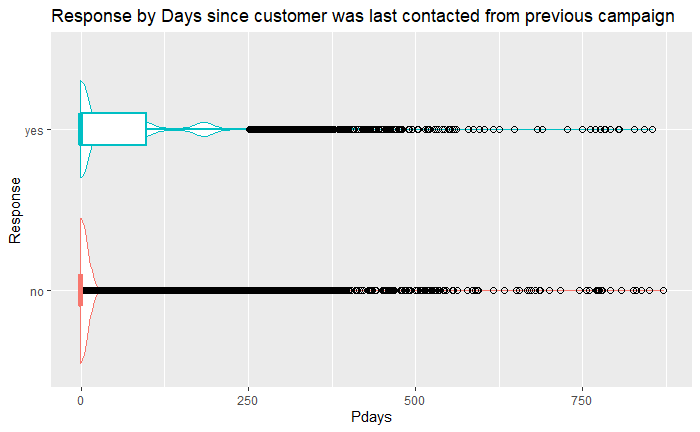

```r
# plot the distribution of pdays
ggplot(bankNum1,
       aes(x = response,
           y = pdays,
           color = response)) +
  geom_violin() +
  geom_boxplot(size=1,
               width = .2,
               outlier.shape = 1,
               outlier.color = "black",
               outlier.size  = 2) +
  scale_y_continuous() +
  labs(title = "Response by Days since customer was last contacted from previous campaign",
       x = "Response",
       y = "Pdays") +
  theme(legend.position = "none") +
  coord_flip()
```

Campaign

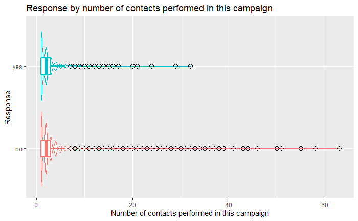

```r
# plot the distribution of age
ggplot(bankNum1,
       aes(x = response,
           y = campaign,
           color = response)) +
  geom_violin() +
  geom_boxplot(size=1,
               width = .2,
               outlier.shape = 1,
               outlier.color = "black",
               outlier.size  = 3) +
  #geom_jitter(alpha = 0.5,
  #            width=.2) +
  scale_y_continuous() +
  labs(title = "Response by number of contacts performed in this campaign",
       x = "Response",
       y = "Number of contacts performed in this campaign") +

  theme(legend.position = "none") +
  coord_flip()
```

Contact

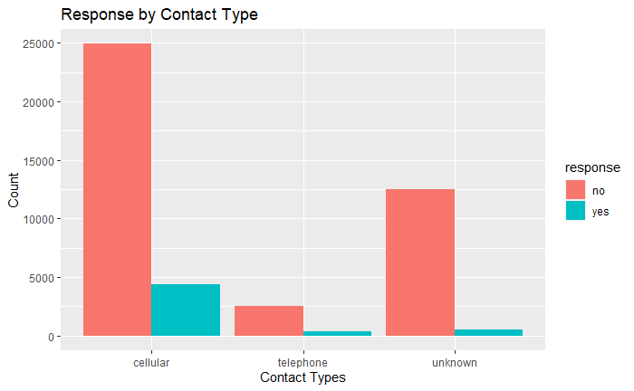

```r
# grouped bar chart
ggplot(data = bankData, aes(x = contact,fill = response)) + geom_bar(position = "dodge")  +
  theme() +
  labs(y = "Count", x = "Contact Types", title = "Response by Contact Type")
```

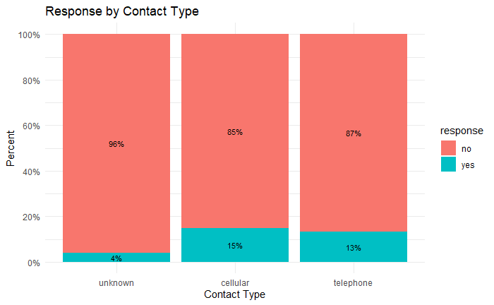

```r
# stacked bar chart with percentages
plotdata <- bankData %>%
  group_by(contact, response) %>%
  summarize(n = n()) %>%
  mutate(pct = n/sum(n),
         lbl = scales::percent(pct))
ggplot(plotdata,
       aes(x = factor(contact,
                      levels = unique(bankData$contact)),
           y = pct,
           fill = factor(response,
                         levels = c("no", "yes"),
                         labels = c("no", "yes")))) +
  geom_bar(stat = "identity",
           position = "fill") +
  scale_y_continuous(breaks = seq(0, 1, .2),
                     label = percent) +
  geom_text(aes(label = lbl),
            size = 3,
            position = position_stack(vjust = 0.5)) +
  labs(x = "Contact Type", y = "Percent", title = "Response by Contact Type", fill="response")+
  theme_minimal()
```

Poutcome

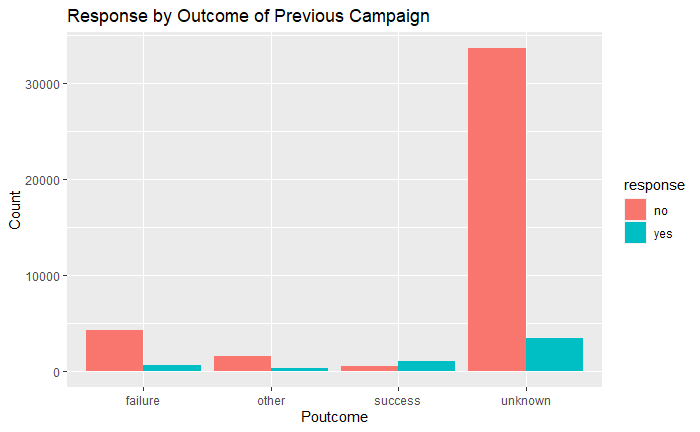

```r
# grouped bar chart
ggplot(data = bankData, aes(x = poutcome,fill = response)) + geom_bar(position = "dodge")  +
  theme() +
  labs(y = "Count", x = "Poutcome", title = "Response by Outcome of Previous Campaign")
```

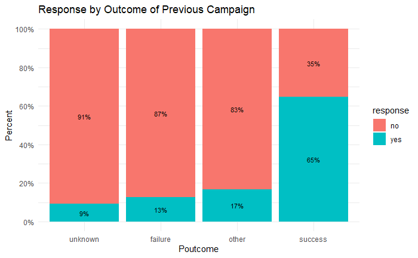

```r
# stacked bar chart with percentages
plotdata <- bankData %>%
  group_by(poutcome, response) %>%
  summarize(n = n()) %>%
  mutate(pct = n/sum(n),
         lbl = scales::percent(pct))
ggplot(plotdata,
       aes(x = factor(poutcome,
                      levels = unique(bankData$poutcome)),
           y = pct,
           fill = factor(response,
                         levels = c("no", "yes"),
                         labels = c("no", "yes")))) +
  geom_bar(stat = "identity",
           position = "fill") +
  scale_y_continuous(breaks = seq(0, 1, .2),
                     label = percent) +
  geom_text(aes(label = lbl),
            size = 3,
            position = position_stack(vjust = 0.5)) +
  labs(x = "Poutcome", y = "Percent", title = "Response by Outcome of Previous Campaign", fill="response")+
  theme_minimal()
```

### Correlation plot for numeric variables

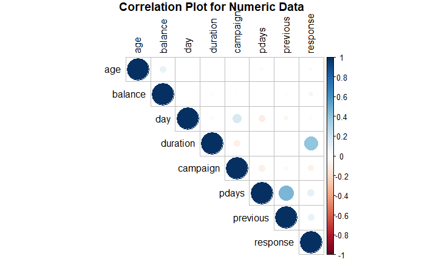

```r
corrData <- copy(bankData)
corrData$response <- as.numeric(factor(corrData$response, levels = c("no", "yes"), exclude = NULL))
# Correlation Matrix
bankNum = corrData[, lapply(corrData, is.numeric) == TRUE, with = FALSE, ]
corrplot(cor(bankNum), type = "upper", title = "Correlation Plot for Numeric Data", mar=c(0,0,1,0),
         tl.cex=1,
         tl.col = "black")
```

## Data Cleaning

```r
newData = copy(bankData)
numCol <- unlist(lapply(newData, is.numeric))
newData <- newData[ , numCol, with=FALSE]
newData$ID <- seq.int(nrow(newData)) # create id
```

### Removing outliers for numeric variables duration and campaign

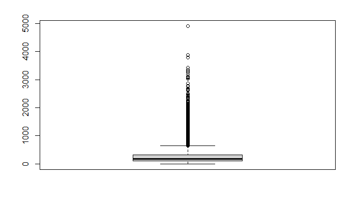

```r
# identify and removing outliers for Duration using boxplot
outliersDur<-boxplot(newData$duration)$out
```

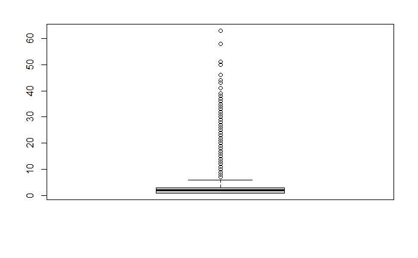

```r
newData<- newData[-which(newData$duration %in% outliersDur),]
# identify and removing outliers for Campaign using boxplot
outliersCam<-boxplot(newData$campaign)$out
```

```r
newData<- newData[-which(newData$campaign %in% outliersCam),]
```

```r
dim(newData)
```

```
[1] 39087     8
```

### Replace unknown with mode for categorical Variables job and education

```r
# create a copy
newCatTemp <- copy(bankData)
catCol <- which(sapply(bankData,is.factor))
newCat <- newCatTemp[ , catCol, with=FALSE]
newCat$ID <- seq.int(nrow(newCat))
```

```r
# find mode
getmode <- function(v) {
   uniqv <- unique(v)
   uniqv[which.max(tabulate(match(v, uniqv)))]
}

jobMode = getmode(newCat$job)
newCat$job[newCat$job == 'unknown'] <- jobMode

eduMode = getmode(newCat$education)
newCat[education=="unknown", education:=eduMode]
head(newCat)
```

| job | marital | education | default | housing | loan | contact | month | poutcome | response | ID |
| --- | --- | --- | --- | --- | --- | --- | --- | --- | --- | --- |
| management | married | tertiary | no | yes | no | unknown | may | unknown | no | 1 |
| technician | single | secondary | no | yes | no | unknown | may | unknown | no | 2 |
| entrepreneur | married | secondary | no | yes | yes | unknown | may | unknown | no | 3 |
| blue-collar | married | secondary | no | yes | no | unknown | may | unknown | no | 4 |
| blue-collar | single | secondary | no | no | no | unknown | may | unknown | no | 5 |
| management | married | tertiary | no | yes | no | unknown | may | unknown | no | 6 |

## Categorical Encoding

### Ordinal encoding for education and month

```r
encode_ordinal <- function(x, order = unique(x)) {
  x <- as.numeric(factor(x, levels = order, exclude = NULL))
  x
}

newCat$encodedEdu = encode_ordinal(newCat$education, order = c("primary", "secondary", "tertiary"))
newCat$encodedMonth = encode_ordinal(newCat$month, order = c("jan", "feb", "mar", "apr", "may", "jun", "jul", "aug", "sep", "oct", "nov", "dec"))
head(newCat)
```

| job | marital | education | default | housing | loan | contact | month | poutcome | response | ID | encodedEdu | encodedMonth |
| --- | --- | --- | --- | --- | --- | --- | --- | --- | --- | --- | --- | --- |
| management | married | tertiary | no | yes | no | unknown | may | unknown | no | 1 | 3 | 5 |
| technician | single | secondary | no | yes | no | unknown | may | unknown | no | 2 | 2 | 5 |
| entrepreneur | married | secondary | no | yes | yes | unknown | may | unknown | no | 3 | 2 | 5 |
| blue-collar | married | secondary | no | yes | no | unknown | may | unknown | no | 4 | 2 | 5 |
| blue-collar | single | secondary | no | no | no | unknown | may | unknown | no | 5 | 2 | 5 |
| management | married | tertiary | no | yes | no | unknown | may | unknown | no | 6 | 3 | 5 |

### One-hot encoding

```r
newCat_OH = copy(newCat)
oneHot <- newCat_OH[, c("job","marital", "housing", "default", "loan", "contact", "poutcome")]
summary(oneHot)
```

```
          job            marital      housing     default      loan            contact         poutcome
 blue-collar:10020   divorced: 5207   no :20081   no :44396   no :37967   cellular :29285   failure: 4901
 management : 9458   married :27214   yes:25130   yes:  815   yes: 7244   telephone: 2906   other  : 1840
 technician : 7597   single  :12790                                       unknown  :13020   success: 1511
 admin.     : 5171                                                                          unknown:36959
 services   : 4154
 retired    : 2264
 (Other)    : 6547
```

```r
oneHot <- one_hot(as.data.table(oneHot))
oneHot$ID <- seq.int(nrow(oneHot))
head(oneHot)
```

| job_admin. | job_blue-collar | job_entrepreneur | job_housemaid | job_management | job_retired | job_self-employed | job_services | job_student | job_technician | job_unemployed | job_unknown | marital_divorced | marital_married | marital_single | housing_no | housing_yes | default_no | default_yes | loan_no | loan_yes | contact_cellular | contact_telephone | contact_unknown | poutcome_failure | poutcome_other | poutcome_success | poutcome_unknown | ID |
| --- | --- | --- | --- | --- | --- | --- | --- | --- | --- | --- | --- | --- | --- | --- | --- | --- | --- | --- | --- | --- | --- | --- | --- | --- | --- | --- | --- | --- |
| 0 | 0 | 0 | 0 | 1 | 0 | 0 | 0 | 0 | 0 | 0 | 0 | 0 | 1 | 0 | 0 | 1 | 1 | 0 | 1 | 0 | 0 | 0 | 1 | 0 | 0 | 0 | 1 | 1 |
| 0 | 0 | 0 | 0 | 0 | 0 | 0 | 0 | 0 | 1 | 0 | 0 | 0 | 0 | 1 | 0 | 1 | 1 | 0 | 1 | 0 | 0 | 0 | 1 | 0 | 0 | 0 | 1 | 2 |
| 0 | 0 | 1 | 0 | 0 | 0 | 0 | 0 | 0 | 0 | 0 | 0 | 0 | 1 | 0 | 0 | 1 | 1 | 0 | 0 | 1 | 0 | 0 | 1 | 0 | 0 | 0 | 1 | 3 |
| 0 | 1 | 0 | 0 | 0 | 0 | 0 | 0 | 0 | 0 | 0 | 0 | 0 | 1 | 0 | 0 | 1 | 1 | 0 | 1 | 0 | 0 | 0 | 1 | 0 | 0 | 0 | 1 | 4 |
| 0 | 1 | 0 | 0 | 0 | 0 | 0 | 0 | 0 | 0 | 0 | 0 | 0 | 0 | 1 | 1 | 0 | 1 | 0 | 1 | 0 | 0 | 0 | 1 | 0 | 0 | 0 | 1 | 5 |
| 0 | 0 | 0 | 0 | 1 | 0 | 0 | 0 | 0 | 0 | 0 | 0 | 0 | 1 | 0 | 0 | 1 | 1 | 0 | 1 | 0 | 0 | 0 | 1 | 0 | 0 | 0 | 1 | 6 |

## Final cleaned data (After Data Cleaning)

```r
finalData <- left_join(newData,newCat, by="ID")
finalData <- left_join(finalData, oneHot, by="ID")
finalData$response = as.numeric(ifelse(finalData$response=="yes", 1, 0))
# drop columns
finalData = finalData[,c("ID","job", "marital", "education", "default", "housing", "loan", "contact", "month", "poutcome", "pdays", "job_unknown"):= NULL]
head(finalData, 50)
```

| age | balance | day | duration | campaign | previous | response | encodedEdu | encodedMonth | job_admin. | job_blue-collar | job_entrepreneur | job_housemaid | job_management | job_retired | job_self-employed | job_services | job_student | job_technician | job_unemployed | marital_divorced | marital_married | marital_single | housing_no | housing_yes | default_no | default_yes | loan_no | loan_yes | contact_cellular | … |
| --- | --- | --- | --- | --- | --- | --- | --- | --- | --- | --- | --- | --- | --- | --- | --- | --- | --- | --- | --- | --- | --- | --- | --- | --- | --- | --- | --- | --- | --- | --- |
| 58 | 2143 | 5 | 261 | 1 | 0 | 0 | 3 | 5 | 0 | 0 | 0 | 0 | 1 | 0 | 0 | 0 | 0 | 0 | 0 | 0 | 1 | 0 | 0 | 1 | 1 | 0 | 1 | 0 | 0 | … |
| 44 | 29 | 5 | 151 | 1 | 0 | 0 | 2 | 5 | 0 | 0 | 0 | 0 | 0 | 0 | 0 | 0 | 0 | 1 | 0 | 0 | 0 | 1 | 0 | 1 | 1 | 0 | 1 | 0 | 0 | … |
| 33 | 2 | 5 | 76 | 1 | 0 | 0 | 2 | 5 | 0 | 0 | 1 | 0 | 0 | 0 | 0 | 0 | 0 | 0 | 0 | 0 | 1 | 0 | 0 | 1 | 1 | 0 | 0 | 1 | 0 | … |
| 47 | 1506 | 5 | 92 | 1 | 0 | 0 | 2 | 5 | 0 | 1 | 0 | 0 | 0 | 0 | 0 | 0 | 0 | 0 | 0 | 0 | 1 | 0 | 0 | 1 | 1 | 0 | 1 | 0 | 0 | … |
| 33 | 1 | 5 | 198 | 1 | 0 | 0 | 2 | 5 | 0 | 1 | 0 | 0 | 0 | 0 | 0 | 0 | 0 | 0 | 0 | 0 | 0 | 1 | 1 | 0 | 1 | 0 | 1 | 0 | 0 | … |
| 35 | 231 | 5 | 139 | 1 | 0 | 0 | 3 | 5 | 0 | 0 | 0 | 0 | 1 | 0 | 0 | 0 | 0 | 0 | 0 | 0 | 1 | 0 | 0 | 1 | 1 | 0 | 1 | 0 | 0 | … |
| 28 | 447 | 5 | 217 | 1 | 0 | 0 | 3 | 5 | 0 | 0 | 0 | 0 | 1 | 0 | 0 | 0 | 0 | 0 | 0 | 0 | 0 | 1 | 0 | 1 | 1 | 0 | 0 | 1 | 0 | … |
| 42 | 2 | 5 | 380 | 1 | 0 | 0 | 3 | 5 | 0 | 0 | 1 | 0 | 0 | 0 | 0 | 0 | 0 | 0 | 0 | 1 | 0 | 0 | 0 | 1 | 0 | 1 | 1 | 0 | 0 | … |
| 58 | 121 | 5 | 50 | 1 | 0 | 0 | 1 | 5 | 0 | 0 | 0 | 0 | 0 | 1 | 0 | 0 | 0 | 0 | 0 | 0 | 1 | 0 | 0 | 1 | 1 | 0 | 1 | 0 | 0 | … |
| 43 | 593 | 5 | 55 | 1 | 0 | 0 | 2 | 5 | 0 | 0 | 0 | 0 | 0 | 0 | 0 | 0 | 0 | 1 | 0 | 0 | 0 | 1 | 0 | 1 | 1 | 0 | 1 | 0 | 0 | … |

[output cut: 40 more lines]

```r
dim(finalData)
```

```
[1] 39087    36
```

```r
Filter(var, finalData) # drop columns with all same value
```

| age | balance | day | duration | campaign | previous | response | encodedEdu | encodedMonth | job_admin. | job_blue-collar | job_entrepreneur | job_housemaid | job_management | job_retired | job_self-employed | job_services | job_student | job_technician | job_unemployed | marital_divorced | marital_married | marital_single | housing_no | housing_yes | default_no | default_yes | loan_no | loan_yes | contact_cellular | … |
| --- | --- | --- | --- | --- | --- | --- | --- | --- | --- | --- | --- | --- | --- | --- | --- | --- | --- | --- | --- | --- | --- | --- | --- | --- | --- | --- | --- | --- | --- | --- |
| 58 | 2143 | 5 | 261 | 1 | 0 | 0 | 3 | 5 | 0 | 0 | 0 | 0 | 1 | 0 | 0 | 0 | 0 | 0 | 0 | 0 | 1 | 0 | 0 | 1 | 1 | 0 | 1 | 0 | 0 | … |
| 44 | 29 | 5 | 151 | 1 | 0 | 0 | 2 | 5 | 0 | 0 | 0 | 0 | 0 | 0 | 0 | 0 | 0 | 1 | 0 | 0 | 0 | 1 | 0 | 1 | 1 | 0 | 1 | 0 | 0 | … |
| 33 | 2 | 5 | 76 | 1 | 0 | 0 | 2 | 5 | 0 | 0 | 1 | 0 | 0 | 0 | 0 | 0 | 0 | 0 | 0 | 0 | 1 | 0 | 0 | 1 | 1 | 0 | 0 | 1 | 0 | … |
| 47 | 1506 | 5 | 92 | 1 | 0 | 0 | 2 | 5 | 0 | 1 | 0 | 0 | 0 | 0 | 0 | 0 | 0 | 0 | 0 | 0 | 1 | 0 | 0 | 1 | 1 | 0 | 1 | 0 | 0 | … |
| 33 | 1 | 5 | 198 | 1 | 0 | 0 | 2 | 5 | 0 | 1 | 0 | 0 | 0 | 0 | 0 | 0 | 0 | 0 | 0 | 0 | 0 | 1 | 1 | 0 | 1 | 0 | 1 | 0 | 0 | … |
| 35 | 231 | 5 | 139 | 1 | 0 | 0 | 3 | 5 | 0 | 0 | 0 | 0 | 1 | 0 | 0 | 0 | 0 | 0 | 0 | 0 | 1 | 0 | 0 | 1 | 1 | 0 | 1 | 0 | 0 | … |
| 28 | 447 | 5 | 217 | 1 | 0 | 0 | 3 | 5 | 0 | 0 | 0 | 0 | 1 | 0 | 0 | 0 | 0 | 0 | 0 | 0 | 0 | 1 | 0 | 1 | 1 | 0 | 0 | 1 | 0 | … |
| 42 | 2 | 5 | 380 | 1 | 0 | 0 | 3 | 5 | 0 | 0 | 1 | 0 | 0 | 0 | 0 | 0 | 0 | 0 | 0 | 1 | 0 | 0 | 0 | 1 | 0 | 1 | 1 | 0 | 0 | … |
| 58 | 121 | 5 | 50 | 1 | 0 | 0 | 1 | 5 | 0 | 0 | 0 | 0 | 0 | 1 | 0 | 0 | 0 | 0 | 0 | 0 | 1 | 0 | 0 | 1 | 1 | 0 | 1 | 0 | 0 | … |
| 43 | 593 | 5 | 55 | 1 | 0 | 0 | 2 | 5 | 0 | 0 | 0 | 0 | 0 | 0 | 0 | 0 | 0 | 1 | 0 | 0 | 0 | 1 | 0 | 1 | 1 | 0 | 1 | 0 | 0 | … |

[output cut: 990 more lines]